# Module 180

#### Contrast SVE:

Signed variance explained (SVE) provides an indication of how similar a set of fold changes are to a gene module’s weight vector. An SVE value of 0.3, for example, indicates that 30% of the variance explained by the entire module set is accounted for by the module in question. Shown here are the SVE values for this module across a compendium of fold changes (contrasts). Extreme SVE values (e.g., > 0.05) indicate that those contrasts specifically induce (orange dots) or specifically repress (blue dots) this module. Examining the experimental conditions being compared in such contrasts (see tables below the figure) may provide insight into the gene module’s function.

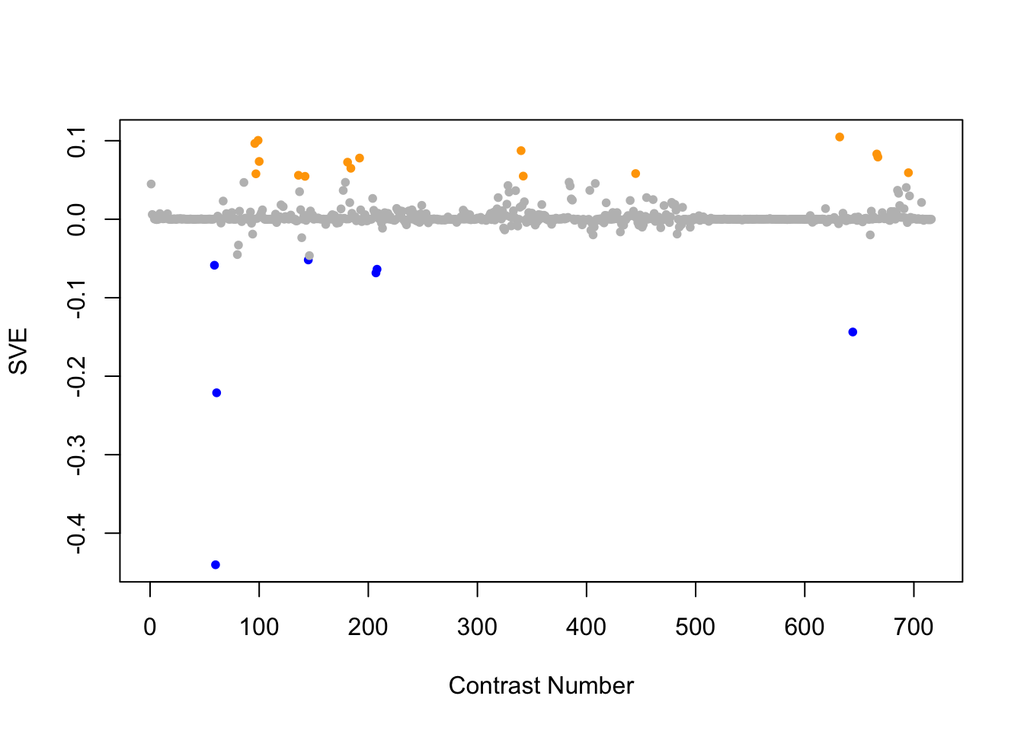

Positive SVE Contrasts:

|  | Contrast.Num | SVE | GEO.GSE | Cond.1 | Cond.2 | Mutation |
| --- | --- | --- | --- | --- | --- | --- |
| GSE19310B.s1t2.vs.s1t1 | 632 | 0.10 | GSE19310 | N2 at 200 for 1 hour, rep1 | N2 at 200 for 15min, rep1 |  |
| GSE5793.s3t2.vs.s1t2 | 99 | 0.10 | GSE5793 | Celegans_PA14_8hours_RepA | Celegans_gacA_8hours_RepA |  |
| GSE5793.s3t1.vs.s1t1 | 96 | 0.10 | GSE5793 | Celegans_PA14_4hours_RepA | Celegans_gacA_4hours_RepA |  |
| GSE38997.s4t1.vs.s1t1 | 340 | 0.09 | GSE38997 | experiment 4 UVC-exposed samples at 3 h 4u3 | experiment 4 control samples at 3 h 4c3 |  |
| GSE15159.s0t2.vs.s0t1 | 666 | 0.08 | GSE15159 | N2_UV_2007_rep1 | N2_control_2007_rep1 |  |
| GSE15159.s2t2.vs.s2t1 | 667 | 0.08 | GSE15159 | xpa-1_UV_2007_rep1 | xpa-1_control_2007_rep1 |  |
| GSE45651.s1t1.vs.s0t1 | 192 | 0.08 | GSE45651 | starved L1 lin-35(n745), biological rep1 | starved L1 wild type worm, biological rep1 | lin-35 |
| GSE5793.s3t2.vs.s2t2 | 100 | 0.07 | GSE5793 | Celegans_PA14_8hours_RepA | Celegans_OP50_8hours_RepA |  |
| GSE47778.s4t3.vs.s4t1 | 181 | 0.07 | GSE47778 | daf-2;daf-16; UV; replicate 1 | daf-2;daf-16; replicate 1 |  |
| GSE47778.s5t3.vs.s5t1 | 184 | 0.06 | GSE47778 | xpa-1 10mJ/cm2; replicate 1 | xpa-1 0mJ/cm2; replicate 1 |  |
| GSE11055.s1t7.vs.s4t7 | 695 | 0.06 | GSE11055 | L1-L2 larvae 15 hr after hatching in the presence of food | L1 larvae fed for 12 hr after hatching and then starved for 3 hr |  |
| GSE27677B.s0t9.vs.s0t7 | 445 | 0.06 | GSE27677 | N2, Fed 48 h, rep 1 | N2, Fed 24 h, rep 1 |  |
| GSE5793.s3t1.vs.s2t1 | 97 | 0.06 | GSE5793 | Celegans_PA14_4hours_RepA | Celegans_OP50_4hours_RepA |  |
| GSE51691.s2t1.vs.s1t1 | 136 | 0.06 | GSE51691 | day8 hermaphrodite +males rep 1 | day8 hermaphrodite -males rep 1 |  |
| GSE38997.s4t1.vs.s2t1 | 342 | 0.05 | GSE38997 | experiment 4 UVC-exposed samples at 3 h 4u3 | experiment 4 EtBr-exposed samples at 3 h 4e3 |  |
| GSE50513.s2t1.vs.s1t1 | 142 | 0.05 | GSE50513 | L4440 PA14 - rep 1 | L4440 OP50 - rep 1 |  |

Negative SVE Contrasts:

|  | Contrast.Num | SVE | GEO.GSE | Cond.1 | Cond.2 | Mutation |
| --- | --- | --- | --- | --- | --- | --- |
| GSE9301.s3t1.vs.s1t1 | 60 | -0.44 | GSE9301 | 3-day-old TJ1090 worms without any stress (C1) | 3-day-old TJ1090 worms with oxidative stress (O1) |  |
| GSE9301.s3t1.vs.s2t1 | 61 | -0.22 | GSE9301 | 3-day-old TJ1090 worms without any stress (C1) | 3-day-old TJ1090 worms with skn-1 RNAi & oxidative stress (SO1) |  |
| GSE16915.s1t1.vs.s3t1 | 644 | -0.14 | GSE16915 | control sample | bio-electrosprayed sample |  |
| GSE42703.s1t2.vs.s1t1 | 207 | -0.07 | GSE42703 | kgb-1 incubated with H2O, biological rep1 | kgb-1 incubated with 1mM copper sulfate, biological rep1 |  |
| GSE42703.s2t2.vs.s2t1 | 208 | -0.06 | GSE42703 | WT incubated with H2O, biological rep1 | WT incubated with 1mM copper sulfate, biological rep1 |  |
| GSE9301.s2t1.vs.s1t1 | 59 | -0.06 | GSE9301 | 3-day-old TJ1090 worms with skn-1 RNAi & oxidative stress (SO1) | 3-day-old TJ1090 worms with oxidative stress (O1) | skn-1 |
| GSE50513.s3t1.vs.s2t1 | 145 | -0.05 | GSE50513 | zip-2 OP50 - rep 1 | L4440 PA14 - rep 1 |  |

$~$

#### Contrast SVE, Up-Regulated Genes Only:

Calculating SVE for up-regulated and down-regulated genes separately may be more informative in many cases than projecting the up- and down- gene sets together. This is due to the fact that the weight distribution of many modules is highly skewed, indicating that only one of the hemi-modules may be biologically meaningful (i.e., a set of genes are strongly correlated by only a few genes (or none) are strongly anti-correlated to that set.)

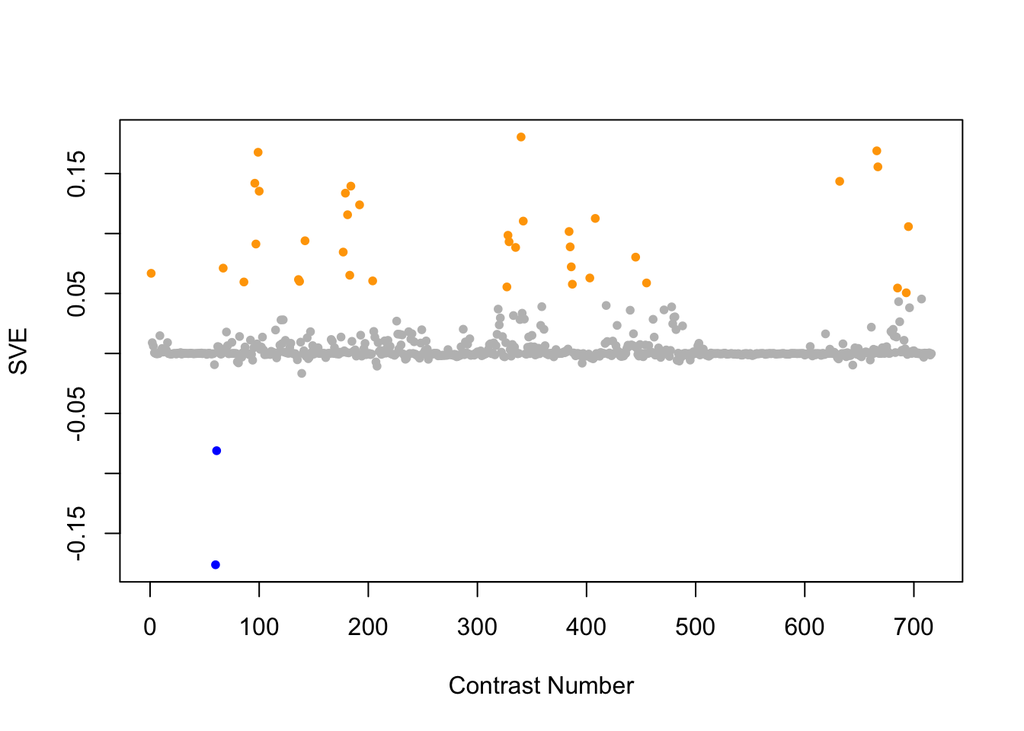

Positive SVE Contrasts:

|  | Contrast.Num | SVE | GEO.GSE | Cond.1 | Cond.2 | Mutation |
| --- | --- | --- | --- | --- | --- | --- |
| GSE38997.s4t1.vs.s1t1 | 340 | 0.18 | GSE38997 | experiment 4 UVC-exposed samples at 3 h 4u3 | experiment 4 control samples at 3 h 4c3 |  |
| GSE15159.s0t2.vs.s0t1 | 666 | 0.17 | GSE15159 | N2_UV_2007_rep1 | N2_control_2007_rep1 |  |
| GSE5793.s3t2.vs.s1t2 | 99 | 0.17 | GSE5793 | Celegans_PA14_8hours_RepA | Celegans_gacA_8hours_RepA |  |
| GSE15159.s2t2.vs.s2t1 | 667 | 0.16 | GSE15159 | xpa-1_UV_2007_rep1 | xpa-1_control_2007_rep1 |  |
| GSE19310B.s1t2.vs.s1t1 | 632 | 0.14 | GSE19310 | N2 at 200 for 1 hour, rep1 | N2 at 200 for 15min, rep1 |  |
| GSE5793.s3t1.vs.s1t1 | 96 | 0.14 | GSE5793 | Celegans_PA14_4hours_RepA | Celegans_gacA_4hours_RepA |  |
| GSE47778.s5t3.vs.s5t1 | 184 | 0.14 | GSE47778 | xpa-1 10mJ/cm2; replicate 1 | xpa-1 0mJ/cm2; replicate 1 |  |
| GSE5793.s3t2.vs.s2t2 | 100 | 0.14 | GSE5793 | Celegans_PA14_8hours_RepA | Celegans_OP50_8hours_RepA |  |
| GSE47778.s2t3.vs.s2t1 | 179 | 0.13 | GSE47778 | daf-2; UV; replicate 1 | daf-2; replicate 1 |  |
| GSE45651.s1t1.vs.s0t1 | 192 | 0.12 | GSE45651 | starved L1 lin-35(n745), biological rep1 | starved L1 wild type worm, biological rep1 | lin-35 |
| GSE47778.s4t3.vs.s4t1 | 181 | 0.12 | GSE47778 | daf-2;daf-16; UV; replicate 1 | daf-2;daf-16; replicate 1 |  |
| GSE30505.s1t1.vs.s2t1 | 408 | 0.11 | GSE30505 | L3 N2 (WT) E.V. #1 | L3 N2 (WT) ash-2 #1 | ash-2 |
| GSE38997.s4t1.vs.s2t1 | 342 | 0.11 | GSE38997 | experiment 4 UVC-exposed samples at 3 h 4u3 | experiment 4 EtBr-exposed samples at 3 h 4e3 |  |
| GSE11055.s1t7.vs.s4t7 | 695 | 0.11 | GSE11055 | L1-L2 larvae 15 hr after hatching in the presence of food | L1 larvae fed for 12 hr after hatching and then starved for 3 hr |  |
| GSE34026.s4t1.vs.s0t1 | 384 | 0.10 | GSE34026 | N2 exposed to CVD109, biological rep1 | N2 exposed to OP50(E.coli), biological rep1 |  |
| GSE38997.s4t4.vs.s1t4 | 328 | 0.10 | GSE38997 | experiment 1 UVC-exposed samples at 51 h 1u51 | experiment 1 control samples at 51 h 1c51 |  |
| GSE50513.s2t1.vs.s1t1 | 142 | 0.09 | GSE50513 | L4440 PA14 - rep 1 | L4440 OP50 - rep 1 |  |
| GSE38997.s3t4.vs.s2t4 | 329 | 0.09 | GSE38997 | experiment 1 UVC- and EtBr-exposed samples at 51 h 1eu51 | experiment 1 EtBr-exposed samples at 51 h 1e51 |  |
| GSE5793.s3t1.vs.s2t1 | 97 | 0.09 | GSE5793 | Celegans_PA14_4hours_RepA | Celegans_OP50_4hours_RepA |  |
| GSE34026.s3t1.vs.s0t1 | 385 | 0.09 | GSE34026 | N2 exposed to CVD110, biological rep1 | N2 exposed to OP50(E.coli), biological rep1 |  |
| GSE38997.s3t2.vs.s2t2 | 335 | 0.09 | GSE38997 | experiment 4 UVC- and EtBr-exposed samples at 24 h 4eu24 | experiment 4 EtBr-exposed samples at 24 h 4e24 |  |
| GSE47778.s3t3.vs.s3t1 | 177 | 0.08 | GSE47778 | daf-16; UV; replicate 1 | daf-16; replicate 1 |  |
| GSE27677B.s0t9.vs.s0t7 | 445 | 0.08 | GSE27677 | N2, Fed 48 h, rep 1 | N2, Fed 24 h, rep 1 |  |
| GSE34026.s2t1.vs.s0t1 | 386 | 0.07 | GSE34026 | N2 exposed to E7946, biological rep1 | N2 exposed to OP50(E.coli), biological rep1 |  |
| GSE8659.s3t1.vs.s2t1 | 67 | 0.07 | GSE8659 | strain NL 2099 replicate 2 | strain GR1373 replicate 1 |  |
| GSE9897A.s1t1.vs.s0t1 | 1 | 0.07 | GSE9897 | Complex I missense mutant | Wildtype (control for missense) | gas-1 |
| GSE47778.s1t3.vs.s1t1 | 183 | 0.07 | GSE47778 | N2; UV; replicate 1 | N2; replicate 1 |  |
| GSE30505.s3t1.vs.s4t1 | 403 | 0.06 | GSE30505 | L3 glp-1 E.V. #1 | L3 glp-1 ash-2 #1 | ash-2 |
| GSE51691.s2t1.vs.s1t1 | 136 | 0.06 | GSE51691 | day8 hermaphrodite +males rep 1 | day8 hermaphrodite -males rep 1 |  |
| GSE43952.s2t1.vs.s0t1 | 204 | 0.06 | GSE43952 | pcca-1(ok2282) fed Comamonas DA1877 rep1 | N2 gravid adult fed Comamonas DA1877 rep 1 | pcca-1 |
| GSE51691.s3t1.vs.s1t1 | 137 | 0.06 | GSE51691 | day8 hermaphrodite utx-1 RNAi -males rep 1 | day8 hermaphrodite -males rep 1 | utx-1(RNAi) |
| GSE6547.s1t1.vs.s0t1 | 86 | 0.06 | GSE6547 | lin-35(n745) worms at embryonic stage, first replicate | N2 (wt) worms at embryonic stage, first replicate | lin-35 |
| GSE25513.s1t1.vs.s0t1 | 455 | 0.06 | GSE25513 | tax-6 null (1) | WT (1) | tax-6 |
| GSE34026.s1t1.vs.s0t1 | 387 | 0.06 | GSE34026 | N2 exposed to hemolysin mutant of E7946, biological rep1 | N2 exposed to OP50(E.coli), biological rep1 |  |
| GSE38997.s3t4.vs.s1t4 | 327 | 0.06 | GSE38997 | experiment 1 UVC- and EtBr-exposed samples at 51 h 1eu51 | experiment 1 control samples at 51 h 1c51 |  |
| GSE12298C.s3t1.vs.s0t1 | 685 | 0.05 | GSE12298 | mefloquine_high_dose-rep1 | mefloquine_control-rep1 |  |
| GSE11055.s1t7.vs.s2t7 | 693 | 0.05 | GSE11055 | L1-L2 larvae 15 hr after hatching in the presence of food | L1 larvae 15 hr after hatching in the absence of food |  |

Negative SVE Contrasts:

|  | Contrast.Num | SVE | GEO.GSE | Cond.1 | Cond.2 | Mutation |
| --- | --- | --- | --- | --- | --- | --- |
| GSE9301.s3t1.vs.s1t1 | 60 | -0.18 | GSE9301 | 3-day-old TJ1090 worms without any stress (C1) | 3-day-old TJ1090 worms with oxidative stress (O1) |  |
| GSE9301.s3t1.vs.s2t1 | 61 | -0.08 | GSE9301 | 3-day-old TJ1090 worms without any stress (C1) | 3-day-old TJ1090 worms with skn-1 RNAi & oxidative stress (SO1) |  |
| GSE51691.s3t1.vs.s2t1 | 139 | -0.02 | GSE51691 | day8 hermaphrodite utx-1 RNAi -males rep 1 | day8 hermaphrodite +males rep 1 |  |
| GSE42703.s2t2.vs.s2t1 | 208 | -0.01 | GSE42703 | WT incubated with H2O, biological rep1 | WT incubated with 1mM copper sulfate, biological rep1 |  |
| GSE16915.s1t1.vs.s3t1 | 644 | -0.01 | GSE16915 | control sample | bio-electrosprayed sample |  |

$~$

#### Contrast SVE, Down-Regulated Genes Only:

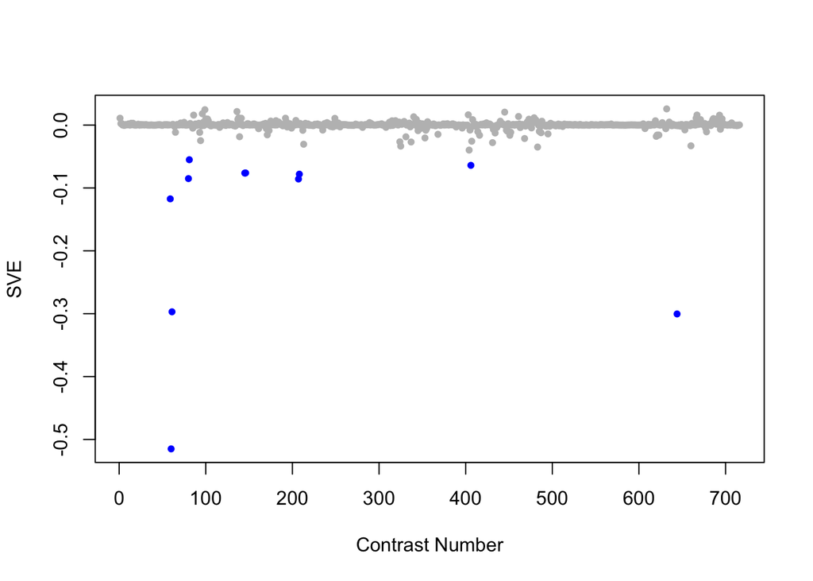

Positive SVE Contrasts:

|  | Contrast.Num | SVE | GEO.GSE | Cond.1 | Cond.2 | Mutation |
| --- | --- | --- | --- | --- | --- | --- |
| GSE19310B.s1t2.vs.s1t1 | 632 | 0.03 | GSE19310 | N2 at 200 for 1 hour, rep1 | N2 at 200 for 15min, rep1 |  |
| GSE5793.s3t2.vs.s1t2 | 99 | 0.02 | GSE5793 | Celegans_PA14_8hours_RepA | Celegans_gacA_8hours_RepA |  |
| GSE51691.s2t1.vs.s1t1 | 136 | 0.02 | GSE51691 | day8 hermaphrodite +males rep 1 | day8 hermaphrodite -males rep 1 |  |
| GSE27677B.s0t9.vs.s0t7 | 445 | 0.02 | GSE27677 | N2, Fed 48 h, rep 1 | N2, Fed 24 h, rep 1 |  |
| GSE5793.s3t1.vs.s1t1 | 96 | 0.02 | GSE5793 | Celegans_PA14_4hours_RepA | Celegans_gacA_4hours_RepA |  |

Negative SVE Contrasts:

|  | Contrast.Num | SVE | GEO.GSE | Cond.1 | Cond.2 | Mutation |
| --- | --- | --- | --- | --- | --- | --- |
| GSE9301.s3t1.vs.s1t1 | 60 | -0.51 | GSE9301 | 3-day-old TJ1090 worms without any stress (C1) | 3-day-old TJ1090 worms with oxidative stress (O1) |  |
| GSE16915.s1t1.vs.s3t1 | 644 | -0.30 | GSE16915 | control sample | bio-electrosprayed sample |  |
| GSE9301.s3t1.vs.s2t1 | 61 | -0.30 | GSE9301 | 3-day-old TJ1090 worms without any stress (C1) | 3-day-old TJ1090 worms with skn-1 RNAi & oxidative stress (SO1) |  |
| GSE9301.s2t1.vs.s1t1 | 59 | -0.12 | GSE9301 | 3-day-old TJ1090 worms with skn-1 RNAi & oxidative stress (SO1) | 3-day-old TJ1090 worms with oxidative stress (O1) | skn-1 |
| GSE42703.s1t2.vs.s1t1 | 207 | -0.09 | GSE42703 | kgb-1 incubated with H2O, biological rep1 | kgb-1 incubated with 1mM copper sulfate, biological rep1 |  |
| GSE8004.s3t2.vs.s3t1 | 80 | -0.09 | GSE8004 | Larval Pan-neural, biological rep 1 of set 2 | Embryonic Pan-neural, biological rep 1 of set 1 |  |
| GSE42703.s2t2.vs.s2t1 | 208 | -0.08 | GSE42703 | WT incubated with H2O, biological rep1 | WT incubated with 1mM copper sulfate, biological rep1 |  |
| GSE50513.s3t1.vs.s2t1 | 145 | -0.08 | GSE50513 | zip-2 OP50 - rep 1 | L4440 PA14 - rep 1 |  |
| GSE50513.s4t1.vs.s2t1 | 146 | -0.08 | GSE50513 | zip-2 PA14 - rep 1 | L4440 PA14 - rep 1 | zip-2 |
| GSE30505.s2t1.vs.s3t1 | 406 | -0.06 | GSE30505 | L3 N2 (WT) ash-2 #1 | L3 glp-1 E.V. #1 | ash-2(RNAi) vs. glp-1 |
| GSE8004.s2t2.vs.s2t1 | 81 | -0.06 | GSE8004 | Larval Reference, biological rep 1 of set 1 | Embryonic Reference, biological rep 1 of set 1 |  |

$~$

$~$

#### GO Term Enrichment:

This analysis tests each hemi-module for enrichment of specific GO terms. Only gene-level annotations (e.g., as would be found on the gene’s page in Wormbase) are tested - the hierarchical structure of the GO ontology is not taken into account.

*Note: At least the top two most enriched terms from each GO domain (BP/MF/CC) are shown, even when not statistically significant.*

##### Enriched GO terms: Hemi-module A

| ID | GO.Term | GO Domain | Raw p-value | Adj p-value |
| --- | --- | --- | --- | --- |
| [GO_0045087](http://amigo.geneontology.org/amigo/term/GO:0045087) | innate immune response | BP | 8.17e-18 | 2.98e-14 |
| [GO_0006418](http://amigo.geneontology.org/amigo/term/GO:0006418) | tRNA aminoacylation for protein translation | BP | 4.61e-11 | 8.40e-08 |
| [GO_0042256](http://amigo.geneontology.org/amigo/term/GO:0042256) | mature ribosome assembly | BP | 2.77e-06 | 3.37e-03 |
| [GO_0010332](http://amigo.geneontology.org/amigo/term/GO:0010332) | response to gamma radiation | BP | 7.56e-06 | 6.89e-03 |
| [GO_0036499](http://amigo.geneontology.org/amigo/term/GO:0036499) | PERK-mediated unfolded protein response | BP | 1.45e-05 | 1.06e-02 |
| [GO_0004812](http://amigo.geneontology.org/amigo/term/GO:0004812) | aminoacyl-tRNA ligase activity | MF | 1.70e-11 | 3.47e-08 |
| [GO_0008194](http://amigo.geneontology.org/amigo/term/GO:0008194) | UDP-glycosyltransferase activity | MF | 2.23e-08 | 2.28e-05 |
| [GO_0016758](http://amigo.geneontology.org/amigo/term/GO:0016758) | transferase activity, transferring hexosyl groups | MF | 6.13e-08 | 4.17e-05 |
| [GO_0016874](http://amigo.geneontology.org/amigo/term/GO:0016874) | ligase activity | MF | 4.38e-06 | 2.24e-03 |
| [GO_0042626](http://amigo.geneontology.org/amigo/term/GO:0042626) | ATPase activity, coupled to transmembrane movement of substances | MF | 5.95e-06 | 2.43e-03 |
| [GO_0000166](http://amigo.geneontology.org/amigo/term/GO:0000166) | nucleotide binding | MF | 1.37e-04 | 4.07e-02 |
| [GO_0043023](http://amigo.geneontology.org/amigo/term/GO:0043023) | ribosomal large subunit binding | MF | 1.47e-04 | 4.07e-02 |
| [GO_0005524](http://amigo.geneontology.org/amigo/term/GO:0005524) | ATP binding | MF | 1.59e-04 | 4.07e-02 |
| [GO_0002161](http://amigo.geneontology.org/amigo/term/GO:0002161) | aminoacyl-tRNA editing activity | MF | 2.19e-04 | 4.96e-02 |
| [GO_0016887](http://amigo.geneontology.org/amigo/term/GO:0016887) | ATPase activity | MF | 3.13e-04 | 6.39e-02 |
| [GO_0000049](http://amigo.geneontology.org/amigo/term/GO:0000049) | tRNA binding | MF | 5.24e-04 | 9.73e-02 |
| [GO_0043231](http://amigo.geneontology.org/amigo/term/GO:0043231) | intracellular membrane-bounded organelle | CC | 8.85e-06 | 8.21e-03 |
| [GO_0017101](http://amigo.geneontology.org/amigo/term/GO:0017101) | aminoacyl-tRNA synthetase multienzyme complex | CC | 2.71e-05 | 1.26e-02 |
| [GO_1990112](http://amigo.geneontology.org/amigo/term/GO:1990112) | RQC complex | CC | 1.98e-04 | 6.14e-02 |

##### Enriched GO terms: Hemi-module B

| ID | GO.Term | GO Domain | Raw p-value | Adj p-value |
| --- | --- | --- | --- | --- |
| [GO_0055114](http://amigo.geneontology.org/amigo/term/GO:0055114) | oxidation-reduction process | BP | 1.31e-04 | 4.78e-01 |
| [GO_0008611](http://amigo.geneontology.org/amigo/term/GO:0008611) | ether lipid biosynthetic process | BP | 3.32e-03 | 1.00e+00 |
| [GO_0016491](http://amigo.geneontology.org/amigo/term/GO:0016491) | oxidoreductase activity | MF | 2.90e-04 | 5.93e-01 |
| [GO_0004658](http://amigo.geneontology.org/amigo/term/GO:0004658) | propionyl-CoA carboxylase activity | MF | 1.66e-03 | 9.25e-01 |
| [GO_0045121](http://amigo.geneontology.org/amigo/term/GO:0045121) | membrane raft | CC | 4.98e-05 | 4.62e-02 |
| [GO_0005778](http://amigo.geneontology.org/amigo/term/GO:0005778) | peroxisomal membrane | CC | 2.14e-02 | 1.00e+00 |

$~$

$~$

#### Tissue Enrichment:

This analysis tests each hemi-module for enrichment of genes associated with anatomy terms. Negative enrichment scores indicate fewer hemi-module genes than expected by random chance were associated with the anatomy term in question.

##### Enriched tissues: Hemi-module A

No significant annotations.

##### Enriched tissues: Hemi-module B

No significant annotations.

$~$

$~$

#### HOMER promoter motif enrichment:

This analysis tests each hemi-module for enrichment of 108 known *C. elegans* transcription factor binding site motifs (see [108 CE motifs](https://katiepod.github.io//all.worm.motifs.html)) using the HOMER (Hypergeometric Optimization of Motif EnRichment) software (see [PMID:20513432](https://pubmed.ncbi.nlm.nih.gov/20513432)). HOMER was run using default parameters on sequences 1 kb upstream of the transcription start site.

##### Motif enrichment: Hemi-module A

Total target sequences = 212  
Total background sequences = 40740  
* - possible false positive

Rank

Motif

P-value

log P-pvalue

% of Targets

% of Background

STD(Bg STD)

Best Match/Details

Motif File

1

[figure not shown]

1e-44

-1.028e+02

28.30%

2.38%

247.4bp (316.9bp)

cebp-1/MA1444.1/Jaspar(0.837)  
[More Information](https://katiepod.github.io/HomerResults/m180_a_hemi_genes.txt.out.1kb/homerResults/motif1.info.html) | [Similar Motifs Found](https://katiepod.github.io/HomerResults/m180_a_hemi_genes.txt.out.1kb/homerResults/motif1.similar.html)

[motif file (matrix)](https://katiepod.github.io/HomerResults/m180_a_hemi_genes.txt.out.1kb/homerResults/motif1.motif)

2 *

[figure not shown]

1e-11

-2.724e+01

33.96%

14.55%

254.9bp (317.2bp)

pqm-1/MA1703.1/Jaspar(0.966)  
[More Information](https://katiepod.github.io/HomerResults/m180_a_hemi_genes.txt.out.1kb/homerResults/motif2.info.html) | [Similar Motifs Found](https://katiepod.github.io/HomerResults/m180_a_hemi_genes.txt.out.1kb/homerResults/motif2.similar.html)

[motif file (matrix)](https://katiepod.github.io/HomerResults/m180_a_hemi_genes.txt.out.1kb/homerResults/motif2.motif)

3 *

[figure not shown]

1e-11

-2.593e+01

16.51%

4.17%

296.8bp (303.9bp)

elt-3/MA0542.1/Jaspar(0.607)  
[More Information](https://katiepod.github.io/HomerResults/m180_a_hemi_genes.txt.out.1kb/homerResults/motif3.info.html) | [Similar Motifs Found](https://katiepod.github.io/HomerResults/m180_a_hemi_genes.txt.out.1kb/homerResults/motif3.similar.html)

[motif file (matrix)](https://katiepod.github.io/HomerResults/m180_a_hemi_genes.txt.out.1kb/homerResults/motif3.motif)

4 *

[figure not shown]

1e-10

-2.465e+01

8.02%

0.89%

307.3bp (297.3bp)

blmp-1/MA0537.1/Jaspar(0.556)  
[More Information](https://katiepod.github.io/HomerResults/m180_a_hemi_genes.txt.out.1kb/homerResults/motif4.info.html) | [Similar Motifs Found](https://katiepod.github.io/HomerResults/m180_a_hemi_genes.txt.out.1kb/homerResults/motif4.similar.html)

[motif file (matrix)](https://katiepod.github.io/HomerResults/m180_a_hemi_genes.txt.out.1kb/homerResults/motif4.motif)

5 *

[figure not shown]

1e-9

-2.293e+01

6.60%

0.61%

262.9bp (319.3bp)

POL002.1_INR/Jaspar(0.511)  
[More Information](https://katiepod.github.io/HomerResults/m180_a_hemi_genes.txt.out.1kb/homerResults/motif5.info.html) | [Similar Motifs Found](https://katiepod.github.io/HomerResults/m180_a_hemi_genes.txt.out.1kb/homerResults/motif5.similar.html)

[motif file (matrix)](https://katiepod.github.io/HomerResults/m180_a_hemi_genes.txt.out.1kb/homerResults/motif5.motif)

6 *

[figure not shown]

1e-9

-2.252e+01

3.30%

0.06%

272.8bp (237.6bp)

unc-62/MA0918.1/Jaspar(0.703)  
[More Information](https://katiepod.github.io/HomerResults/m180_a_hemi_genes.txt.out.1kb/homerResults/motif6.info.html) | [Similar Motifs Found](https://katiepod.github.io/HomerResults/m180_a_hemi_genes.txt.out.1kb/homerResults/motif6.similar.html)

[motif file (matrix)](https://katiepod.github.io/HomerResults/m180_a_hemi_genes.txt.out.1kb/homerResults/motif6.motif)

7 *

[figure not shown]

1e-9

-2.228e+01

24.53%

9.56%

274.2bp (308.5bp)

MF0011.1_HMG_class/Jaspar(0.682)  
[More Information](https://katiepod.github.io/HomerResults/m180_a_hemi_genes.txt.out.1kb/homerResults/motif7.info.html) | [Similar Motifs Found](https://katiepod.github.io/HomerResults/m180_a_hemi_genes.txt.out.1kb/homerResults/motif7.similar.html)

[motif file (matrix)](https://katiepod.github.io/HomerResults/m180_a_hemi_genes.txt.out.1kb/homerResults/motif7.motif)

8 *

[figure not shown]

1e-9

-2.227e+01

2.83%

0.03%

316.5bp (306.1bp)

PL0010.1_hlh-2::hlh-19/Jaspar(0.522)  
[More Information](https://katiepod.github.io/HomerResults/m180_a_hemi_genes.txt.out.1kb/homerResults/motif8.info.html) | [Similar Motifs Found](https://katiepod.github.io/HomerResults/m180_a_hemi_genes.txt.out.1kb/homerResults/motif8.similar.html)

[motif file (matrix)](https://katiepod.github.io/HomerResults/m180_a_hemi_genes.txt.out.1kb/homerResults/motif8.motif)

9 *

[figure not shown]

1e-9

-2.213e+01

11.79%

2.50%

317.4bp (292.8bp)

POL013.1_MED-1/Jaspar(0.570)  
[More Information](https://katiepod.github.io/HomerResults/m180_a_hemi_genes.txt.out.1kb/homerResults/motif9.info.html) | [Similar Motifs Found](https://katiepod.github.io/HomerResults/m180_a_hemi_genes.txt.out.1kb/homerResults/motif9.similar.html)

[motif file (matrix)](https://katiepod.github.io/HomerResults/m180_a_hemi_genes.txt.out.1kb/homerResults/motif9.motif)

10 *

[figure not shown]

1e-9

-2.206e+01

5.19%

0.33%

177.5bp (297.5bp)

unc-30/MA1443.1/Jaspar(0.626)  
[More Information](https://katiepod.github.io/HomerResults/m180_a_hemi_genes.txt.out.1kb/homerResults/motif10.info.html) | [Similar Motifs Found](https://katiepod.github.io/HomerResults/m180_a_hemi_genes.txt.out.1kb/homerResults/motif10.similar.html)

[motif file (matrix)](https://katiepod.github.io/HomerResults/m180_a_hemi_genes.txt.out.1kb/homerResults/motif10.motif)

11 *

[figure not shown]

1e-9

-2.146e+01

6.60%

0.68%

284.1bp (304.4bp)

PHA-4(Forkhead)/cElegans-Embryos-PHA4-ChIP-Seq(modEncode)/Homer(0.524)  
[More Information](https://katiepod.github.io/HomerResults/m180_a_hemi_genes.txt.out.1kb/homerResults/motif11.info.html) | [Similar Motifs Found](https://katiepod.github.io/HomerResults/m180_a_hemi_genes.txt.out.1kb/homerResults/motif11.similar.html)

[motif file (matrix)](https://katiepod.github.io/HomerResults/m180_a_hemi_genes.txt.out.1kb/homerResults/motif11.motif)

12 *

[figure not shown]

1e-9

-2.104e+01

4.72%

0.27%

223.8bp (321.4bp)

MF0004.1_Nuclear_Receptor_class/Jaspar(0.573)  
[More Information](https://katiepod.github.io/HomerResults/m180_a_hemi_genes.txt.out.1kb/homerResults/motif12.info.html) | [Similar Motifs Found](https://katiepod.github.io/HomerResults/m180_a_hemi_genes.txt.out.1kb/homerResults/motif12.similar.html)

[motif file (matrix)](https://katiepod.github.io/HomerResults/m180_a_hemi_genes.txt.out.1kb/homerResults/motif12.motif)

13 *

[figure not shown]

1e-9

-2.094e+01

3.77%

0.13%

233.3bp (219.3bp)

skn-1/MA0547.1/Jaspar(0.658)  
[More Information](https://katiepod.github.io/HomerResults/m180_a_hemi_genes.txt.out.1kb/homerResults/motif13.info.html) | [Similar Motifs Found](https://katiepod.github.io/HomerResults/m180_a_hemi_genes.txt.out.1kb/homerResults/motif13.similar.html)

[motif file (matrix)](https://katiepod.github.io/HomerResults/m180_a_hemi_genes.txt.out.1kb/homerResults/motif13.motif)

14 *

[figure not shown]

1e-9

-2.078e+01

5.66%

0.47%

294.6bp (296.0bp)

lin-14/MA0261.1/Jaspar(0.525)  
[More Information](https://katiepod.github.io/HomerResults/m180_a_hemi_genes.txt.out.1kb/homerResults/motif14.info.html) | [Similar Motifs Found](https://katiepod.github.io/HomerResults/m180_a_hemi_genes.txt.out.1kb/homerResults/motif14.similar.html)

[motif file (matrix)](https://katiepod.github.io/HomerResults/m180_a_hemi_genes.txt.out.1kb/homerResults/motif14.motif)

15 *

[figure not shown]

1e-8

-2.029e+01

12.26%

2.96%

245.8bp (320.5bp)

EGL-5(Homeobox)/cElegans-L3-EGL5-ChIP-Seq(modEncode)/Homer(0.673)  
[More Information](https://katiepod.github.io/HomerResults/m180_a_hemi_genes.txt.out.1kb/homerResults/motif15.info.html) | [Similar Motifs Found](https://katiepod.github.io/HomerResults/m180_a_hemi_genes.txt.out.1kb/homerResults/motif15.similar.html)

[motif file (matrix)](https://katiepod.github.io/HomerResults/m180_a_hemi_genes.txt.out.1kb/homerResults/motif15.motif)

16 *

[figure not shown]

1e-8

-2.027e+01

3.77%

0.14%

242.4bp (241.5bp)

POL004.1_CCAAT-box/Jaspar(0.552)  
[More Information](https://katiepod.github.io/HomerResults/m180_a_hemi_genes.txt.out.1kb/homerResults/motif16.info.html) | [Similar Motifs Found](https://katiepod.github.io/HomerResults/m180_a_hemi_genes.txt.out.1kb/homerResults/motif16.similar.html)

[motif file (matrix)](https://katiepod.github.io/HomerResults/m180_a_hemi_genes.txt.out.1kb/homerResults/motif16.motif)

17 *

[figure not shown]

1e-8

-1.967e+01

11.32%

2.61%

304.7bp (306.9bp)

eor-1/MA0543.1/Jaspar(0.778)  
[More Information](https://katiepod.github.io/HomerResults/m180_a_hemi_genes.txt.out.1kb/homerResults/motif17.info.html) | [Similar Motifs Found](https://katiepod.github.io/HomerResults/m180_a_hemi_genes.txt.out.1kb/homerResults/motif17.similar.html)

[motif file (matrix)](https://katiepod.github.io/HomerResults/m180_a_hemi_genes.txt.out.1kb/homerResults/motif17.motif)

18 *

[figure not shown]

1e-8

-1.964e+01

8.49%

1.43%

212.6bp (287.9bp)

cebp-1/MA1444.1/Jaspar(0.503)  
[More Information](https://katiepod.github.io/HomerResults/m180_a_hemi_genes.txt.out.1kb/homerResults/motif18.info.html) | [Similar Motifs Found](https://katiepod.github.io/HomerResults/m180_a_hemi_genes.txt.out.1kb/homerResults/motif18.similar.html)

[motif file (matrix)](https://katiepod.github.io/HomerResults/m180_a_hemi_genes.txt.out.1kb/homerResults/motif18.motif)

19 *

[figure not shown]

1e-7

-1.785e+01

2.83%

0.07%

265.3bp (310.8bp)

fkh-9/MA1440.1/Jaspar(0.614)  
[More Information](https://katiepod.github.io/HomerResults/m180_a_hemi_genes.txt.out.1kb/homerResults/motif19.info.html) | [Similar Motifs Found](https://katiepod.github.io/HomerResults/m180_a_hemi_genes.txt.out.1kb/homerResults/motif19.similar.html)

[motif file (matrix)](https://katiepod.github.io/HomerResults/m180_a_hemi_genes.txt.out.1kb/homerResults/motif19.motif)

20 *

[figure not shown]

1e-7

-1.763e+01

8.02%

1.44%

276.6bp (310.2bp)

PL0002.1_hlh-2::hlh-3/Jaspar(0.546)  
[More Information](https://katiepod.github.io/HomerResults/m180_a_hemi_genes.txt.out.1kb/homerResults/motif20.info.html) | [Similar Motifs Found](https://katiepod.github.io/HomerResults/m180_a_hemi_genes.txt.out.1kb/homerResults/motif20.similar.html)

[motif file (matrix)](https://katiepod.github.io/HomerResults/m180_a_hemi_genes.txt.out.1kb/homerResults/motif20.motif)

21 *

[figure not shown]

1e-7

-1.647e+01

9.43%

2.19%

244.8bp (309.8bp)

POL012.1_TATA-Box/Jaspar(0.555)  
[More Information](https://katiepod.github.io/HomerResults/m180_a_hemi_genes.txt.out.1kb/homerResults/motif21.info.html) | [Similar Motifs Found](https://katiepod.github.io/HomerResults/m180_a_hemi_genes.txt.out.1kb/homerResults/motif21.similar.html)

[motif file (matrix)](https://katiepod.github.io/HomerResults/m180_a_hemi_genes.txt.out.1kb/homerResults/motif21.motif)

22 *

[figure not shown]

1e-6

-1.604e+01

2.83%

0.10%

302.7bp (294.0bp)

POL006.1_BREu/Jaspar(0.489)  
[More Information](https://katiepod.github.io/HomerResults/m180_a_hemi_genes.txt.out.1kb/homerResults/motif22.info.html) | [Similar Motifs Found](https://katiepod.github.io/HomerResults/m180_a_hemi_genes.txt.out.1kb/homerResults/motif22.similar.html)

[motif file (matrix)](https://katiepod.github.io/HomerResults/m180_a_hemi_genes.txt.out.1kb/homerResults/motif22.motif)

23 *

[figure not shown]

1e-6

-1.560e+01

8.96%

2.09%

284.8bp (289.9bp)

lin-54/MA1450.1/Jaspar(0.558)  
[More Information](https://katiepod.github.io/HomerResults/m180_a_hemi_genes.txt.out.1kb/homerResults/motif23.info.html) | [Similar Motifs Found](https://katiepod.github.io/HomerResults/m180_a_hemi_genes.txt.out.1kb/homerResults/motif23.similar.html)

[motif file (matrix)](https://katiepod.github.io/HomerResults/m180_a_hemi_genes.txt.out.1kb/homerResults/motif23.motif)

24 *

[figure not shown]

1e-6

-1.542e+01

8.49%

1.90%

227.3bp (309.2bp)

ceh-48/MA0921.1/Jaspar(0.570)  
[More Information](https://katiepod.github.io/HomerResults/m180_a_hemi_genes.txt.out.1kb/homerResults/motif24.info.html) | [Similar Motifs Found](https://katiepod.github.io/HomerResults/m180_a_hemi_genes.txt.out.1kb/homerResults/motif24.similar.html)

[motif file (matrix)](https://katiepod.github.io/HomerResults/m180_a_hemi_genes.txt.out.1kb/homerResults/motif24.motif)

25 *

[figure not shown]

1e-6

-1.525e+01

32.55%

17.94%

276.2bp (304.5bp)

che-1/MA0260.1/Jaspar(0.578)  
[More Information](https://katiepod.github.io/HomerResults/m180_a_hemi_genes.txt.out.1kb/homerResults/motif25.info.html) | [Similar Motifs Found](https://katiepod.github.io/HomerResults/m180_a_hemi_genes.txt.out.1kb/homerResults/motif25.similar.html)

[motif file (matrix)](https://katiepod.github.io/HomerResults/m180_a_hemi_genes.txt.out.1kb/homerResults/motif25.motif)

26 *

[figure not shown]

1e-6

-1.432e+01

30.19%

16.50%

284.3bp (309.5bp)

MF0009.1_TRP(MYB)_class/Jaspar(0.502)  
[More Information](https://katiepod.github.io/HomerResults/m180_a_hemi_genes.txt.out.1kb/homerResults/motif26.info.html) | [Similar Motifs Found](https://katiepod.github.io/HomerResults/m180_a_hemi_genes.txt.out.1kb/homerResults/motif26.similar.html)

[motif file (matrix)](https://katiepod.github.io/HomerResults/m180_a_hemi_genes.txt.out.1kb/homerResults/motif26.motif)

27 *

[figure not shown]

1e-5

-1.253e+01

6.13%

1.24%

291.2bp (299.7bp)

MF0004.1_Nuclear_Receptor_class/Jaspar(0.719)  
[More Information](https://katiepod.github.io/HomerResults/m180_a_hemi_genes.txt.out.1kb/homerResults/motif27.info.html) | [Similar Motifs Found](https://katiepod.github.io/HomerResults/m180_a_hemi_genes.txt.out.1kb/homerResults/motif27.similar.html)

[motif file (matrix)](https://katiepod.github.io/HomerResults/m180_a_hemi_genes.txt.out.1kb/homerResults/motif27.motif)

28 *

[figure not shown]

1e-5

-1.197e+01

4.25%

0.59%

297.3bp (310.7bp)

POL012.1_TATA-Box/Jaspar(0.713)  
[More Information](https://katiepod.github.io/HomerResults/m180_a_hemi_genes.txt.out.1kb/homerResults/motif28.info.html) | [Similar Motifs Found](https://katiepod.github.io/HomerResults/m180_a_hemi_genes.txt.out.1kb/homerResults/motif28.similar.html)

[motif file (matrix)](https://katiepod.github.io/HomerResults/m180_a_hemi_genes.txt.out.1kb/homerResults/motif28.motif)

29 *

[figure not shown]

1e-5

-1.196e+01

2.83%

0.20%

285.6bp (300.8bp)

PL0017.1_hlh-2::hlh-10/Jaspar(0.606)  
[More Information](https://katiepod.github.io/HomerResults/m180_a_hemi_genes.txt.out.1kb/homerResults/motif29.info.html) | [Similar Motifs Found](https://katiepod.github.io/HomerResults/m180_a_hemi_genes.txt.out.1kb/homerResults/motif29.similar.html)

[motif file (matrix)](https://katiepod.github.io/HomerResults/m180_a_hemi_genes.txt.out.1kb/homerResults/motif29.motif)

30 *

[figure not shown]

1e-5

-1.174e+01

4.25%

0.60%

172.6bp (257.4bp)

DPL-1(E2F)/cElegans-Adult-ChIP-Seq(modEncode)/Homer(0.508)  
[More Information](https://katiepod.github.io/HomerResults/m180_a_hemi_genes.txt.out.1kb/homerResults/motif30.info.html) | [Similar Motifs Found](https://katiepod.github.io/HomerResults/m180_a_hemi_genes.txt.out.1kb/homerResults/motif30.similar.html)

[motif file (matrix)](https://katiepod.github.io/HomerResults/m180_a_hemi_genes.txt.out.1kb/homerResults/motif30.motif)

31 *

[figure not shown]

1e-4

-1.011e+01

17.92%

9.05%

272.2bp (312.5bp)

zfh-2/MA0928.1/Jaspar(0.704)  
[More Information](https://katiepod.github.io/HomerResults/m180_a_hemi_genes.txt.out.1kb/homerResults/motif31.info.html) | [Similar Motifs Found](https://katiepod.github.io/HomerResults/m180_a_hemi_genes.txt.out.1kb/homerResults/motif31.similar.html)

[motif file (matrix)](https://katiepod.github.io/HomerResults/m180_a_hemi_genes.txt.out.1kb/homerResults/motif31.motif)

32 *

[figure not shown]

1e-1

-4.311e+00

5.66%

2.70%

252.5bp (278.6bp)

POL003.1_GC-box/Jaspar(0.736)  
[More Information](https://katiepod.github.io/HomerResults/m180_a_hemi_genes.txt.out.1kb/homerResults/motif32.info.html) | [Similar Motifs Found](https://katiepod.github.io/HomerResults/m180_a_hemi_genes.txt.out.1kb/homerResults/motif32.similar.html)

[motif file (matrix)](https://katiepod.github.io/HomerResults/m180_a_hemi_genes.txt.out.1kb/homerResults/motif32.motif)

##### Motif enrichment: Hemi-module B

Total target sequences = 25  
Total background sequences = 38452  
* - possible false positive

Rank

Motif

P-value

log P-pvalue

% of Targets

% of Background

STD(Bg STD)

Best Match/Details

Motif File

1 *

[figure not shown]

1e-10

-2.310e+01

40.00%

2.27%

229.3bp (300.3bp)

MF0009.1_TRP(MYB)_class/Jaspar(0.531)  
[More Information](https://katiepod.github.io/HomerResults/m180_b_hemi_genes.txt.out.1kb/homerResults/motif1.info.html) | [Similar Motifs Found](https://katiepod.github.io/HomerResults/m180_b_hemi_genes.txt.out.1kb/homerResults/motif1.similar.html)

[motif file (matrix)](https://katiepod.github.io/HomerResults/m180_b_hemi_genes.txt.out.1kb/homerResults/motif1.motif)

2 *

[figure not shown]

1e-9

-2.255e+01

24.00%

0.31%

314.5bp (301.7bp)

POL008.1_DCE_S_I/Jaspar(0.488)  
[More Information](https://katiepod.github.io/HomerResults/m180_b_hemi_genes.txt.out.1kb/homerResults/motif2.info.html) | [Similar Motifs Found](https://katiepod.github.io/HomerResults/m180_b_hemi_genes.txt.out.1kb/homerResults/motif2.similar.html)

[motif file (matrix)](https://katiepod.github.io/HomerResults/m180_b_hemi_genes.txt.out.1kb/homerResults/motif2.motif)

3 *

[figure not shown]

1e-8

-2.058e+01

16.00%

0.05%

250.2bp (325.8bp)

unc-30/MA1443.1/Jaspar(0.571)  
[More Information](https://katiepod.github.io/HomerResults/m180_b_hemi_genes.txt.out.1kb/homerResults/motif3.info.html) | [Similar Motifs Found](https://katiepod.github.io/HomerResults/m180_b_hemi_genes.txt.out.1kb/homerResults/motif3.similar.html)

[motif file (matrix)](https://katiepod.github.io/HomerResults/m180_b_hemi_genes.txt.out.1kb/homerResults/motif3.motif)

4 *

[figure not shown]

1e-6

-1.590e+01

56.00%

11.78%

273.4bp (335.4bp)

POL009.1_DCE_S_II/Jaspar(0.511)  
[More Information](https://katiepod.github.io/HomerResults/m180_b_hemi_genes.txt.out.1kb/homerResults/motif4.info.html) | [Similar Motifs Found](https://katiepod.github.io/HomerResults/m180_b_hemi_genes.txt.out.1kb/homerResults/motif4.similar.html)

[motif file (matrix)](https://katiepod.github.io/HomerResults/m180_b_hemi_genes.txt.out.1kb/homerResults/motif4.motif)

5 *

[figure not shown]

1e-6

-1.517e+01

20.00%

0.55%

328.8bp (292.8bp)

PL0017.1_hlh-2::hlh-10/Jaspar(0.624)  
[More Information](https://katiepod.github.io/HomerResults/m180_b_hemi_genes.txt.out.1kb/homerResults/motif5.info.html) | [Similar Motifs Found](https://katiepod.github.io/HomerResults/m180_b_hemi_genes.txt.out.1kb/homerResults/motif5.similar.html)

[motif file (matrix)](https://katiepod.github.io/HomerResults/m180_b_hemi_genes.txt.out.1kb/homerResults/motif5.motif)

6 *

[figure not shown]

1e-6

-1.459e+01

52.00%

10.92%

208.9bp (319.7bp)

ceh-48/MA0921.1/Jaspar(0.635)  
[More Information](https://katiepod.github.io/HomerResults/m180_b_hemi_genes.txt.out.1kb/homerResults/motif6.info.html) | [Similar Motifs Found](https://katiepod.github.io/HomerResults/m180_b_hemi_genes.txt.out.1kb/homerResults/motif6.similar.html)

[motif file (matrix)](https://katiepod.github.io/HomerResults/m180_b_hemi_genes.txt.out.1kb/homerResults/motif6.motif)

7 *

[figure not shown]

1e-6

-1.406e+01

40.00%

5.93%

195.5bp (302.5bp)

che-1/MA0260.1/Jaspar(0.677)  
[More Information](https://katiepod.github.io/HomerResults/m180_b_hemi_genes.txt.out.1kb/homerResults/motif7.info.html) | [Similar Motifs Found](https://katiepod.github.io/HomerResults/m180_b_hemi_genes.txt.out.1kb/homerResults/motif7.similar.html)

[motif file (matrix)](https://katiepod.github.io/HomerResults/m180_b_hemi_genes.txt.out.1kb/homerResults/motif7.motif)

8 *

[figure not shown]

1e-5

-1.204e+01

8.00%

0.01%

92.2bp (216.2bp)

PL0016.1_ref-1/Jaspar(0.554)  
[More Information](https://katiepod.github.io/HomerResults/m180_b_hemi_genes.txt.out.1kb/homerResults/motif8.info.html) | [Similar Motifs Found](https://katiepod.github.io/HomerResults/m180_b_hemi_genes.txt.out.1kb/homerResults/motif8.similar.html)

[motif file (matrix)](https://katiepod.github.io/HomerResults/m180_b_hemi_genes.txt.out.1kb/homerResults/motif8.motif)

9 *

[figure not shown]

1e-4

-1.137e+01

20.00%

1.21%

236.7bp (312.7bp)

HLH-1(bHLH)/cElegans-Embryo-HLH1-ChIP-Seq(modEncode)/Homer(0.684)  
[More Information](https://katiepod.github.io/HomerResults/m180_b_hemi_genes.txt.out.1kb/homerResults/motif9.info.html) | [Similar Motifs Found](https://katiepod.github.io/HomerResults/m180_b_hemi_genes.txt.out.1kb/homerResults/motif9.similar.html)

[motif file (matrix)](https://katiepod.github.io/HomerResults/m180_b_hemi_genes.txt.out.1kb/homerResults/motif9.motif)

10 *

[figure not shown]

1e-4

-1.113e+01

36.00%

6.41%

248.1bp (310.7bp)

MF0002.1_bZIP_CREB/G-box-like_subclass/Jaspar(0.684)  
[More Information](https://katiepod.github.io/HomerResults/m180_b_hemi_genes.txt.out.1kb/homerResults/motif10.info.html) | [Similar Motifs Found](https://katiepod.github.io/HomerResults/m180_b_hemi_genes.txt.out.1kb/homerResults/motif10.similar.html)

[motif file (matrix)](https://katiepod.github.io/HomerResults/m180_b_hemi_genes.txt.out.1kb/homerResults/motif10.motif)

11 *

[figure not shown]

1e-4

-1.029e+01

28.00%

3.87%

344.4bp (310.4bp)

MF0010.1_Homeobox_class/Jaspar(0.570)  
[More Information](https://katiepod.github.io/HomerResults/m180_b_hemi_genes.txt.out.1kb/homerResults/motif11.info.html) | [Similar Motifs Found](https://katiepod.github.io/HomerResults/m180_b_hemi_genes.txt.out.1kb/homerResults/motif11.similar.html)

[motif file (matrix)](https://katiepod.github.io/HomerResults/m180_b_hemi_genes.txt.out.1kb/homerResults/motif11.motif)

12 *

[figure not shown]

1e-3

-8.058e+00

24.00%

3.87%

286.8bp (286.1bp)

ceh-38/MA1699.1/Jaspar(0.672)  
[More Information](https://katiepod.github.io/HomerResults/m180_b_hemi_genes.txt.out.1kb/homerResults/motif12.info.html) | [Similar Motifs Found](https://katiepod.github.io/HomerResults/m180_b_hemi_genes.txt.out.1kb/homerResults/motif12.similar.html)

[motif file (matrix)](https://katiepod.github.io/HomerResults/m180_b_hemi_genes.txt.out.1kb/homerResults/motif12.motif)

13 *

[figure not shown]

1e-2

-6.774e+00

16.00%

1.87%

119.2bp (314.4bp)

MF0004.1_Nuclear_Receptor_class/Jaspar(0.701)  
[More Information](https://katiepod.github.io/HomerResults/m180_b_hemi_genes.txt.out.1kb/homerResults/motif13.info.html) | [Similar Motifs Found](https://katiepod.github.io/HomerResults/m180_b_hemi_genes.txt.out.1kb/homerResults/motif13.similar.html)

[motif file (matrix)](https://katiepod.github.io/HomerResults/m180_b_hemi_genes.txt.out.1kb/homerResults/motif13.motif)

14 *

[figure not shown]

1e-2

-6.194e+00

44.00%

17.68%

289.5bp (311.6bp)

sma-4/MA0925.1/Jaspar(0.648)  
[More Information](https://katiepod.github.io/HomerResults/m180_b_hemi_genes.txt.out.1kb/homerResults/motif14.info.html) | [Similar Motifs Found](https://katiepod.github.io/HomerResults/m180_b_hemi_genes.txt.out.1kb/homerResults/motif14.similar.html)

[motif file (matrix)](https://katiepod.github.io/HomerResults/m180_b_hemi_genes.txt.out.1kb/homerResults/motif14.motif)

$~$

$~$

#### Promoter Word Enrichment:

This analysis tests each hemi-module for enrichment of specific promoter words. The list of promoter words tested was generated by running the MobyDick algorithm (see [PMID:10944202](https://pubmed.ncbi.nlm.nih.gov/10944202)) on the full set of *C. elegans* 2 Kbp promoters.

##### Enriched promoter words: Hemi-module A

| Word | RC | Raw.p.value | Adj.p.value |
| --- | --- | --- | --- |
| TATAAATA | TATTTATA | 8.15e-06 | 4.26e-02 |

##### Enriched promoter words: Hemi-module B

No significant words.

$~$

$~$

#### Promoter Word Depletion:

This analysis tests each hemi-module for depletion (under-enrichment) of specific promoter words. The list of promoter words tested was generated by running the MobyDick algorithm (see [PMID:10944202](https://pubmed.ncbi.nlm.nih.gov/10944202)) on the full set of *C. elegans* 2 Kbp promoters.

##### Depleted promoter words: Hemi-module A

No significant words.

##### Depleted promoter words: Hemi-module B

No significant words.

$~$

$~$

#### 3’-UTR Word Enrichment:

This analysis tests each hemi-module for enrichment of specific 3’-UTR words. The list of words tested was generated by running the MobyDick algorithm (see [PMID:10944202](https://pubmed.ncbi.nlm.nih.gov/10944202)) on the full set of *C. elegans* 3’-UTR sequences.

##### 3’-UTR words: Hemi-module A

No significant words.

##### 3’-UTR words: Hemi-module B

| Word | RC | Raw.p.value | Adj.p.value |
| --- | --- | --- | --- |
| AAA | TTT | 9.95e-05 | 9.57e-02 |

$~$

$~$

#### Hemi-module A genes

| affy_c_elegans | ensembl_gene_id | external_gene_name | module_weight | chromosome_name | strand | start_position | end_position |
| --- | --- | --- | --- | --- | --- | --- | --- |
| 185055_at | WBGene00015695 | ugt-26 | 18.44 | I | 1 | 4721131 | 4723960 |
| 183876_at | WBGene00015574 | irg-1 | 17.75 | V | 1 | 3523587 | 3524575 |
| 188998_s_at | WBGene00003999 | pgp-5 | 17.63 | X | -1 | 10854320 | 10859297 |
| 179226_at | WBGene00007366 | C06B3.7 | 16.00 | V | 1 | 13909686 | 13911524 |
| 176819_s_at | WBGene00021709 | ugt-29 | 15.77 | V | -1 | 696523 | 699614 |
| 189364_at | WBGene00004052 | parg-2 | 15.76 | IV | -1 | 8712635 | 8715027 |
| 189041_s_at | WBGene00004000 | pgp-6 | 15.75 | X | -1 | 10871181 | 10877465 |
| 189041_s_at | WBGene00004001 | pgp-7 | 15.75 | X | -1 | 10864969 | 10870237 |
| 189344_s_at | WBGene00000373 | cyp-14A5 | 14.22 | V | -1 | 5421018 | 5423488 |
| 176256_s_at | WBGene00021978 | Y58A7A.4 | 14.01 | V | -1 | 5082002 | 5085007 |
| 176141_s_at | WBGene00021977 | Y58A7A.3 | 12.92 | V | -1 | 5077849 | 5080903 |
| 179214_at | WBGene00010019 | F54B8.4 | 12.73 | V | 1 | 15816464 | 15817143 |
| 180192_at | WBGene00016783 | irg-2 | 12.21 | V | 1 | 4042404 | 4043599 |
| 180193_at | WBGene00017467 | F14F9.4 | 11.80 | V | 1 | 5132741 | 5137100 |
| 176209_at | WBGene00021979 | Y58A7A.5 | 11.79 | V | -1 | 5085886 | 5086969 |
| 176453_at | WBGene00021464 | ugt-31 | 11.62 | I | 1 | 2333312 | 2338693 |
| 185076_at | WBGene00018708 | oac-32 | 11.23 | V | -1 | 1542517 | 1545791 |
| 173777_s_at | WBGene00000562 | cng-1 | 11.14 | V | -1 | 15025740 | 15031473 |
| 183940_at | WBGene00018966 | F56D2.5 | 10.98 | III | -1 | 5578435 | 5581343 |
| 179563_at | WBGene00007717 | C25D7.5 | 10.93 | V | 1 | 15053765 | 15056280 |
| 181695_at | WBGene00077593 | C49G7.12 | 10.76 | V | 1 | 4038821 | 4039934 |
| 177152_at | WBGene00021556 | Y45G5AM.3 | 10.72 | V | 1 | 4164554 | 4166825 |
| 180797_s_at | WBGene00008698 | F11D11.3 | 10.70 | V | -1 | 18757982 | 18760285 |
| 180797_s_at | WBGene00271804 | F11D11.22 | 10.70 | V | 1 | 18762344 | 18763526 |
| 177336_at | WBGene00000795 | crn-2 | 10.49 | V | 1 | 5594615 | 5595842 |
| 179599_at | WBGene00013947 | ZK228.4 | 9.71 | V | 1 | 18462804 | 18465320 |
| 185328_at | WBGene00015693 | ugt-28 | 9.60 | I | 1 | 4727280 | 4730366 |
| 191917_at | WBGene00012130 | slc-17.4 | 9.49 | IV | -1 | 17288171 | 17291733 |
| 179610_s_at | WBGene00011799 | T16G1.5 | 9.40 | V | -1 | 12937654 | 12939506 |
| 184711_at | WBGene00016788 | C49G7.10 | 9.07 | V | -1 | 4040409 | 4042004 |

[output cut: 263 more lines]

#### Hemi-module B genes

| affy_c_elegans | ensembl_gene_id | external_gene_name | module_weight | chromosome_name | strand | start_position | end_position |
| --- | --- | --- | --- | --- | --- | --- | --- |
| 179098_at | WBGene00011844 | T19C9.8 | -4.47 | V | 1 | 17239097 | 17240656 |
| 190954_at | WBGene00010791 | sodh-2 | -4.09 | V | -1 | 11889719 | 11891194 |
| 189681_at | WBGene00009729 | F45E10.2 | -4.04 | II | -1 | 11052140 | 11055303 |
| 193653_s_at | WBGene00017864 | pcca-1 | -4.02 | X | -1 | 7657538 | 7687738 |
| 187191_at | WBGene00015410 | tbc-6 | -3.98 | II | 1 | 6848060 | 6851531 |
| 182951_at | WBGene00016361 | drd-10 | -3.67 | V | 1 | 7007612 | 7008299 |
| 193068_at | WBGene00003877 | pept-1 | -3.63 | X | 1 | 6456687 | 6461767 |
| 191274_s_at | WBGene00003958 | pcp-3 | -3.63 | IV | -1 | 9155079 | 9159019 |
| 190200_at | WBGene00008127 | ddo-1 | -3.58 | V | -1 | 17774187 | 17777227 |
| 189633_at | WBGene00015045 | cyp-34A10 | -3.56 | V | -1 | 3970712 | 3973001 |
| 190884_at | WBGene00007808 | best-7 | -3.55 | IV | -1 | 11226502 | 11230307 |
| 188046_s_at | WBGene00001581 | gfi-1 | -3.53 | V | -1 | 6392541 | 6399921 |
| 175815_at | WBGene00021337 | Y34F4.2 | -3.50 | III | 1 | 1010535 | 1011385 |
| 175424_at | WBGene00008042 | C40H1.7 | -3.46 | III | 1 | 9325048 | 9327031 |
| 180425_s_at | WBGene00017484 | F15E6.3 | -3.46 | IV | 1 | 4294877 | 4295687 |
| 180424_at | WBGene00017484 | F15E6.3 | -3.43 | IV | 1 | 4294877 | 4295687 |
| 171934_x_at | WBGene00010959 | nduo-1 | -3.42 | MtDNA | 1 | 1763 | 2635 |
| 190786_s_at | WBGene00012445 | Y16B4A.2 | -3.41 | X | -1 | 14761966 | 14771885 |
| 190620_s_at | WBGene00000111 | alh-5 | -3.37 | V | -1 | 1996100 | 1999581 |
| 189142_at | WBGene00007140 | cyp-29A4 | -3.37 | V | 1 | 9654755 | 9657975 |
| 186464_s_at | WBGene00012911 | acl-7 | -3.35 | II | -1 | 12811802 | 12816462 |
| 179857_s_at | WBGene00017703 | F22E5.1 | -3.32 | II | 1 | 2673908 | 2677588 |
| 179857_s_at | WBGene00021298 | Y27F2A.6 | -3.32 | II | -1 | 3180479 | 3182676 |
| 179187_s_at | WBGene00009787 | F46F2.3 | -3.31 | X | -1 | 15259579 | 15260290 |
| 187282_at | WBGene00017698 | F22B7.9 | -3.30 | III | -1 | 8652578 | 8653925 |
| 182849_at | WBGene00012538 | Y37A1B.5 | -3.27 | IV | 1 | 14051200 | 14056676 |
| 188927_at | WBGene00006628 | tsp-2 | -3.24 | III | -1 | 8236984 | 8237881 |
| 185879_at | WBGene00018907 | F55G1.15 | -3.22 | IV | -1 | 7498129 | 7501437 |
| 179502_at | WBGene00012123 | T28D6.3 | -3.22 | III | 1 | 11366618 | 11368435 |
| 182081_s_at | WBGene00044697 | poml-4 | -3.20 | II | 1 | 1540928 | 1542718 |
| 182081_s_at | WBGene00077701 | poml-3 | -3.20 | I | -1 | 4145315 | 4147182 |
| 176702_at | WBGene00016103 | dpyd-1 | -3.17 | X | 1 | 5467870 | 5472684 |
| 181195_at | WBGene00010175 | F56H11.2 | -3.17 | IV | -1 | 9531357 | 9533171 |
| 190301_s_at | WBGene00000136 | amt-4 | -3.17 | X | 1 | 4565302 | 4569393 |
| 192338_at | WBGene00002012 | hsp-12.3 | -3.14 | IV | -1 | 9444791 | 9445507 |
| 188282_at | WBGene00002016 | hsp-16.2 | -3.13 | V | -1 | 1804334 | 1804971 |
| 189753_at | WBGene00010684 | K08F9.1 | -3.12 | V | -1 | 15137273 | 15139888 |
| 177350_at | WBGene00010947 | M176.11 | -3.12 | II | 1 | 9422269 | 9423296 |
| 173926_at | WBGene00017864 | pcca-1 | -3.12 | X | -1 | 7657538 | 7687738 |
| 186740_s_at | WBGene00021999 | thn-5 | -3.09 | IV | 1 | 5230830 | 5232479 |
| 186740_s_at | WBGene00022001 | thn-7 | -3.09 | IV | -1 | 5237918 | 5240353 |
| 185525_at | WBGene00015399 | cyp-35A1 | -3.07 | V | -1 | 7359935 | 7361773 |
| 189554_at | WBGene00007549 | spin-1 | -3.07 | V | 1 | 12114993 | 12117443 |
| 186313_at | WBGene00013037 | Y49E10.18 | -3.06 | III | -1 | 12442630 | 12446145 |
| 186714_s_at | WBGene00013986 | ZK512.7 | -3.06 | III | -1 | 9138052 | 9138701 |
| 192878_at | WBGene00002259 | lbp-7 | -3.04 | V | 1 | 13879552 | 13880213 |
| 186713_at | WBGene00013986 | ZK512.7 | -3.04 | III | -1 | 9138052 | 9138701 |
| 179856_at | WBGene00017703 | F22E5.1 | -3.03 | II | 1 | 2673908 | 2677588 |
| 173282_s_at | WBGene00006609 | tre-3 | -3.03 | V | -1 | 11709775 | 11715903 |